# R Notebook

```r
# loading required packages and setting qiime2 environment
Sys.setenv(PATH = paste0(Sys.getenv("PATH"), ":/Users/wangkai/opt/anaconda3/envs/qiime2/bin"))
library(tidyverse)

if (!requireNamespace("BiocManager", quietly=TRUE))
    install.packages("BiocManager")
if (!requireNamespace("MicrobiotaProcess", quietly=TRUE))
    BiocManager::install("MicrobiotaProcess")
library(MicrobiotaProcess)
library(ggsci)
```

# 1. Data preparation

## 1.1 Extract data from Qiime2 artifact files

```r
# bray curtis
system('qiime tools export \\
          --input-path Data/1-feature-table_bac.qza \\
          --output-path Data/')
```

```
Exported Data/1-feature-table_bac.qza as BIOMV210DirFmt to directory Data/
```

```r
system('mv Data/feature-table.biom Data/1-feature-table_bac.biom')
system('biom convert -i Data/1-feature-table_bac.biom -o Data/1-feature-table_bac.tsv --to-tsv')

system('qiime tools export \\
          --input-path Data/1-feature-table_arc.qza \\
          --output-path Data/')
```

```
Exported Data/1-feature-table_arc.qza as BIOMV210DirFmt to directory Data/
```

```r
system('mv Data/feature-table.biom Data/1-feature-table_arc.biom')
system('biom convert -i Data/1-feature-table_arc.biom -o Data/1-feature-table_arc.tsv --to-tsv')
```

```r
system('qiime tools export \\
          --input-path Results/3-taxonomy_bac.qza \\
          --output-path Results/')
```

```
Exported Results/3-taxonomy_bac.qza as TSVTaxonomyDirectoryFormat to directory Results/
```

```r
system('mv Results/taxonomy.tsv Results/3-taxonomy_bac.tsv')

system('qiime tools export \\
          --input-path Results/3-taxonomy_arc.qza \\
          --output-path Results/')
```

```
Exported Results/3-taxonomy_arc.qza as TSVTaxonomyDirectoryFormat to directory Results/
```

```r
system('mv Results/taxonomy.tsv Results/3-taxonomy_arc.tsv')
```

## 1.2 Load feature table and taxonomy

```r
feature_table_bac <- read.delim("Data/1-feature-table_bac.tsv", skip = 1, row.names = 1)
feature_table_arc <- read.delim("Data/1-feature-table_arc.tsv", skip = 1, row.names = 1)
taxonomy_bac <- read.delim("Results/3-taxonomy_bac.tsv", row.names = 1)
taxonomy_arc <- read.delim("Results/3-taxonomy_arc.tsv", row.names = 1)
```

## 1.3 Curate metadata

Column `Title` in the metadata contains information about animal identification and PCR library types, which are retrieved here. A and B stand for corresponding archaea or bacteria library.

```r
metadata <- read.delim('Data/0-exported-metadata/sra-metadata.tsv', row.names = 1, check.names = FALSE)

metadata[, 'Animal_ID'] <- str_extract(string = metadata$Title, pattern = '[0-9][0-9]')
metadata[, 'PCR'] <- ifelse(str_detect(metadata$Title, 'A$'), 'A', 'B')
```

Column `Description [sample]` contains information about diet treatments [Diet], and sample types [Phase] from which parts of rumen contents samples were collected. However, period of treatment cannot be inferred here with a high confidence, random effect of period will not be considered in linear mixed models.

```r
metadata[, 'Phase'] <- do.call(paste,
                               data.frame(
                                 str_split_fixed(
                                   string = metadata$`Description [sample]`,
                                   pattern = ' ', n = 3)[, 1:2]))
metadata[, 'Diet'] <- str_split_fixed(string = metadata$`Description [sample]`, pattern = ' ', n = 3)[, 3]
metadata$Phase <- factor(metadata$Phase, levels = c("solid phase", "liquid phase", "rumen fluid"),
                         labels = c("Solid phase", "Liquid phase", "Rumen fluid"))

metadata$Diet <- factor(metadata$Diet, levels = c("corn", "grass", "hay"),
                         labels = c("Corn silage", "Grass silage", "Grass hay"))
```

Select columns needed for analysis

```r
metadata <- metadata[c('Animal_ID', 'PCR', 'Phase', 'Diet')]
metadata[, 'Animal_ID'] <- as.factor(metadata[, 'Animal_ID'])
head(metadata)
```

|  | Animal_ID | PCR | Phase | Diet |
| --- | --- | --- | --- | --- |
| ERR1842970 | 23 | B | Rumen fluid | Corn silage |
| ERR1842971 | 59 | B | Rumen fluid | Corn silage |
| ERR1842972 | 28 | B | Rumen fluid | Corn silage |
| ERR1842973 | 28 | B | Rumen fluid | Grass silage |
| ERR1842974 | 23 | B | Rumen fluid | Grass silage |
| ERR1842975 | 59 | B | Rumen fluid | Grass silage |

Subsets of metadata for two PCR libraries.

```r
metadata_bac <- subset(metadata, PCR == "B")
metadata_arc <- subset(metadata, PCR == "A")
```

Check if sample names and feature names are matched.

```r
identical(rownames(feature_table_arc), rownames(taxonomy_arc))
```

```
[1] TRUE
```

```r
identical(colnames(feature_table_arc), rownames(metadata_arc))
```

```
[1] TRUE
```

```r
identical(rownames(feature_table_bac), rownames(taxonomy_bac))
```

```
[1] TRUE
```

```r
identical(colnames(feature_table_bac), rownames(metadata_bac))
```

```
[1] TRUE
```

# 2 Taxonomy curation

## 2.1 Define a function for taxonomy curation

```r
tidy_tax<-function(tax){

  tax <- data.frame(str_split_fixed(tax$Taxon, "; " ,7),row.names = rownames(tax))
  tax <- apply(tax, 2, function(x){
    x[grep("^[^a-z_]",x)]<-""
    return(x)
  })
  tax<-apply(tax,2,function(x)substring(x,4))

  tax <- as.data.frame(tax)
  colnames(tax)<-c("Kingdom","Phylum","Class","Order","Family","Genus","Species")
  return(tax)
}
```

## 2.2 Taxonomy curation

```r
taxonomy_arc <- tidy_tax(taxonomy_arc)
taxonomy_bac <- tidy_tax(taxonomy_bac)
```

# 3. Feature and taxonomy filtering

Taxonomy of PCR library amplified by Arch349-Arch806 primers contains bacterial species, these bacteria are deleted from taxonomy.

```r
taxonomy_arc <- subset(taxonomy_arc, Kingdom == "Archaea")
feature_table_arc <- feature_table_arc[rownames(taxonomy_arc), ]
```

ASVs that are present in at least 3 samples were remained. This can improve resolution and limit FDR (false discovery rate) penalty on features that are too far below the noise threshold to be applicable to a statistical test.

```r
feature_table_bac <-  feature_table_bac[rowSums(feature_table_bac>0) > 2, ]
feature_table_arc <-  feature_table_arc[rowSums(feature_table_arc>0) > 2, ]
```

# 4. Differential taxa: Bacteria

## 4.1 Differential taxa between phases

LEfSe analysis

```r
lefse_phase_bac <- diff_analysis(data.frame(t(feature_table_bac)),
                 sampleda = metadata_bac,
                 taxda = taxonomy_bac,
                 classgroup = "Phase", subclass = "Diet",

                 mlfun="lda",
                 clwilc=FALSE, #whether to perform test of per classgroup, default is TRUE
                 strictmod = FALSE, # whether to performed in one-against-one, default is TRUE (strict), when subgroup is provided
                 padjust = "fdr",
                 filtermod="fdr",
                 firstcomfun = "kruskal.test",
                 firstalpha=0.01,
                 secondcomfun = "wilcox.test",
                 secondalpha=0.01,
                 lda=3
                 )
lefse_phase_bac
```

```
The original data: 496 features and 27 samples
The sample data: 2 variables and 27 samples
The taxda contained 8128 by 7 rank
after first test (kruskal.test) number of feature (fdr<=0.01):39
after second test (generalizedFC) number of significantly discriminative feature:39
after lda, Number of discriminative features: 27 (certain taxonomy classification:19; uncertain taxonomy classication: 8)
```

Clade plot

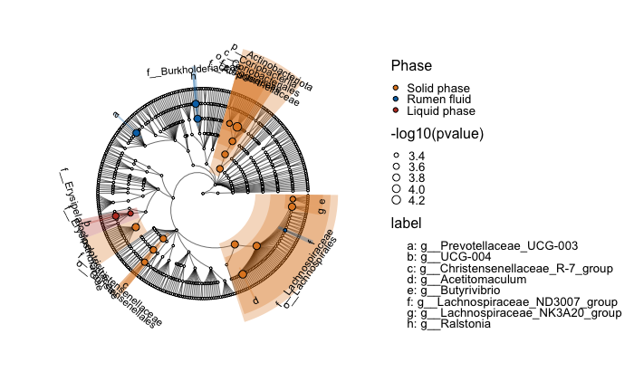

```r
clade_phase_bac <- lefse_phase_bac %>%
  ggdiffclade(obj=.,
              alpha=0.3, linewd=0.2, cladetext = 3, reduce = FALSE,
              skpointsize=0.6,
              taxlevel=6,
              settheme=FALSE,
              setColors=FALSE) +
  scale_fill_nejm()+
  guides(color = guide_legend(keywidth = 0.5,
                              keyheight = 0.5,
                              order = 3)) +
  guides(fill=guide_legend(order = 1,reverse = T,keyheight = 0.5,keywidth = 0.5))+
  theme(panel.background=element_rect(fill=NA),
        legend.position="right",
        legend.spacing.y = unit(0.3, "cm"),
        legend.title=element_text(size=12),
        legend.text=element_text(size=10))
clade_phase_bac
ggsave("Results/3-Differential_taxa_phase_bac.png", clade_phase_bac, width = 9, height = 6)
```

Box plot

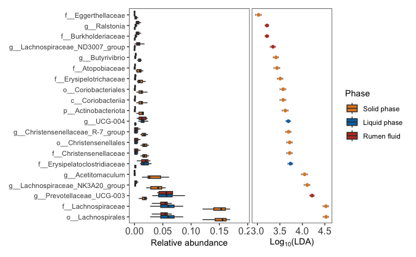

```r
box_phase_bac <- lefse_phase_bac %>%
  ggdiffbox(obj=.,
            box_notch=FALSE, box_width = 0.08,
            colorlist=pal_nejm()(3),
            l_xlabtext="Relative abundance")
box_phase_bac


ggsave("Results/3-Differential_taxa_phase_boxplot_bac.png",box_phase_bac, width = 9, height = 6)
```

## 4.2 Differential taxa between diets

LEfSe analysis

```r
lefse_diet_bac <- diff_analysis(data.frame(t(feature_table_bac)),
                 sampleda = metadata_bac,
                 taxda = taxonomy_bac,
                 classgroup = "Diet", subclass = "Phase",

                 mlfun = "lda",
                 clwilc = FALSE, #whether to perform test of per classgroup, default is TRUE
                 strictmod = FALSE, # whether to performed in one-against-one, default is TRUE (strict), when subgroup is provided
                 padjust = "fdr",
                 filtermod = "pvalue",
                 firstcomfun = "kruskal.test",
                 firstalpha = 0.01,
                 secondcomfun = "wilcox.test",
                 secondalpha = 0.01,
                 lda = 3
                 )
lefse_diet_bac
```

```
The original data: 496 features and 27 samples
The sample data: 2 variables and 27 samples
The taxda contained 8128 by 7 rank
after first test (kruskal.test) number of feature (pvalue<=0.01):43
after second test (generalizedFC) number of significantly discriminative feature:43
after lda, Number of discriminative features: 39 (certain taxonomy classification:26; uncertain taxonomy classication: 13)
```

Clade plot

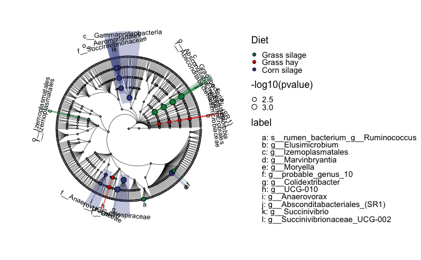

```r
clade_diet_bac <- lefse_diet_bac %>%
  ggdiffclade(obj=.,
              alpha=0.3, linewd=0.2, cladetext = 3, reduce = FALSE,
              skpointsize=0.6,
              taxlevel=6,
              settheme=FALSE,
              setColors=FALSE) +
  scale_fill_aaas()+
  guides(color = guide_legend(keywidth = 0.5,
                              keyheight = 0.5,
                              order = 3)) +
  guides(fill=guide_legend(order = 1,reverse = T,keyheight = 0.5,keywidth = 0.5))+
  theme(panel.background=element_rect(fill=NA),
        legend.position="right",
        legend.spacing.y = unit(0.3, "cm"),
        legend.title=element_text(size=12),
        legend.text=element_text(size=10))
clade_diet_bac
ggsave("Results/3-Differential_taxa_diet_bac.png", clade_diet_bac, width = 9, height = 6)
```

Box plot

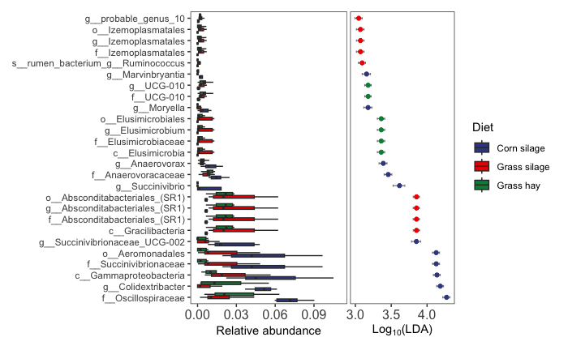

```r
box_diet_bac <- lefse_diet_bac %>%
  ggdiffbox(obj=.,
            box_notch=FALSE, box_width = 0.08,
            colorlist=pal_aaas()(3),
            l_xlabtext="Relative abundance")

box_diet_bac

ggsave("Results/3-Differential_taxa_diet_boxplot_bac.png",box_diet_bac, width = 9, height = 6)
```

# 5. Differential taxa: Archaea

## 5.1 Differential taxa between phases

LEfSe analysis

```r
lefse_phase_arc <- diff_analysis(data.frame(t(feature_table_arc)),
                 sampleda = metadata_arc,
                 taxda = taxonomy_arc,
                 classgroup = "Phase", subclass = "Diet",

                 mlfun="lda",
                 clwilc=FALSE, #whether to perform test of per classgroup, default is TRUE
                 strictmod = FALSE, # whether to performed in one-against-one, default is TRUE (strict), when subgroup is provided
                 padjust = "fdr",
                 filtermod="fdr",
                 firstcomfun = "kruskal.test",
                 firstalpha=0.05,
                 secondcomfun = "wilcox.test",
                 secondalpha=0.05,
                 lda=3
                 )
lefse_phase_arc
```

```
The original data: 20 features and 27 samples
The sample data: 2 variables and 27 samples
The taxda contained 61 by 7 rank
after first test (kruskal.test) number of feature (fdr<=0.05):13
after second test (generalizedFC) number of significantly discriminative feature:13
after lda, Number of discriminative features: 13 (certain taxonomy classification:9; uncertain taxonomy classication: 4)
```

Clade plot

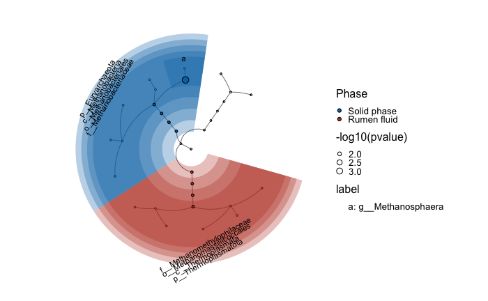

```r
clade_phase_arc <- lefse_phase_arc %>%
  ggdiffclade(obj=.,
              alpha=0.3, linewd=0.2, cladetext = 3, reduce = FALSE,
              skpointsize=0.6,
              taxlevel=6,
              settheme=FALSE,
              setColors=FALSE) +
  scale_fill_nejm()+
  guides(color = guide_legend(keywidth = 0.5,
                              keyheight = 0.5,
                              order = 3)) +
  guides(fill=guide_legend(order = 1,reverse = T,keyheight = 0.5,keywidth = 0.5))+
  theme(panel.background=element_rect(fill=NA),
        legend.position="right",
        legend.spacing.y = unit(0.3, "cm"),
        legend.title=element_text(size=12),
        legend.text=element_text(size=10))
clade_phase_arc
ggsave("Results/3-Differential_taxa_phase_arc.png", clade_phase_arc, width = 9, height = 6)
```

Box plot

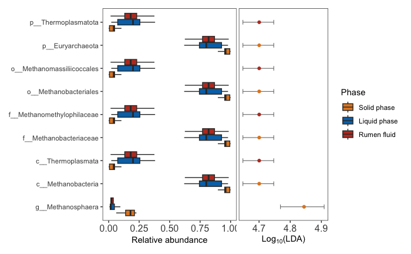

```r
box_phase_arc <- lefse_phase_arc %>%
  ggdiffbox(obj=.,
            box_notch=FALSE, box_width = 0.08,
            colorlist=pal_nejm()(3),
            l_xlabtext="Relative abundance")

box_phase_arc

ggsave("Results/3-Differential_taxa_phase_boxplot_arc.png",box_phase_arc, width = 9, height = 6)
```

## 5.2 Differential taxa between diets

LEfSe analysis

```r
lefse_diet_arc <- diff_analysis(data.frame(t(feature_table_arc)),
                 sampleda = metadata_arc,
                 taxda = taxonomy_arc,
                 classgroup = "Diet", subclass = "Phase",

                 mlfun = "lda",
                 clwilc = FALSE, #whether to perform test of per classgroup, default is TRUE
                 strictmod = FALSE, # whether to performed in one-against-one, default is TRUE (strict), when subgroup is provided
                 padjust = "fdr",
                 filtermod = "pvalue",
                 firstcomfun = "kruskal.test",
                 firstalpha = 0.05,
                 secondcomfun = "wilcox.test",
                 secondalpha = 0.05,
                 lda = 3
                 )
lefse_diet_arc
```

```
The original data: 20 features and 27 samples
The sample data: 2 variables and 27 samples
The taxda contained 61 by 7 rank
after first test (kruskal.test) number of feature (pvalue<=0.05):4
after second test (generalizedFC) number of significantly discriminative feature:4
after lda, Number of discriminative features: 4 (certain taxonomy classification:3; uncertain taxonomy classication: 1)
```

Clade plot

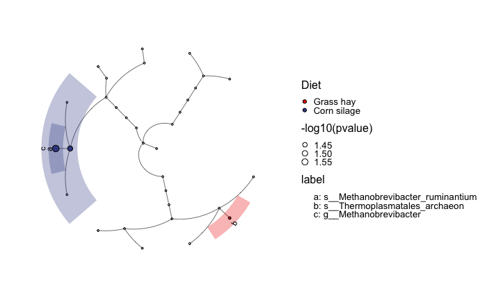

```r
clade_diet_arc <- lefse_diet_arc %>%
  ggdiffclade(obj=.,
              alpha=0.3, linewd=0.2, cladetext = 3, reduce = FALSE,
              skpointsize=0.6,
              taxlevel=6,
              settheme=FALSE,
              setColors=FALSE) +
  scale_fill_aaas()+
  guides(color = guide_legend(keywidth = 0.5,
                              keyheight = 0.5,
                              order = 3)) +
  guides(fill=guide_legend(order = 1,reverse = T,keyheight = 0.5,keywidth = 0.5))+
  theme(legend.position="right",
        legend.spacing.y = unit(0.3, "cm"),
        legend.title=element_text(size=12),
        legend.text=element_text(size=10))
clade_diet_arc
ggsave("Results/3-Differential_taxa_diet_arc.png", clade_diet_arc, width = 9, height = 6)
```

Box plot

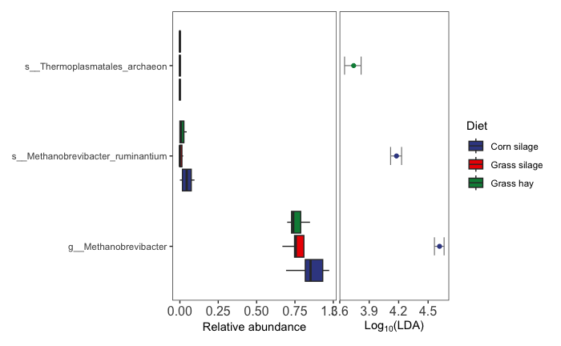

```r
box_diet_arc <- ggdiffbox(lefse_diet_arc,
                          box_notch=FALSE, box_width = 0.08,
                          colorlist=pal_aaas()(3),
                          l_xlabtext="Relative abundance")
box_diet_arc

ggsave("Results/3-Differential_taxa_diet_boxplot_arc.png",box_diet_arc, width = 9, height = 6)
```